Direct

# Frutificando em Cristonos nossos recursos

Mordomia da vida, do tempo e de tudo o que recebemos

## Qual foi o seu primeiro pensamento quando ouviu que o tema era sobre recursos?

Imagino que a maior parte aqui tenha pensado em

DINHEIRO.

- Mas nós, jovens, temos recursos de maior potencial do que o dinheiro: energia, gana, tempo e aprendizado.
- Hoje, o objetivo é identificar esses recursos e entender como frutificar neles.

O primeiro passo para frutificar nos nossos recursos é entender, de fato, o que é um recurso.

## O que é um recurso?

Aquilo de que podemos lançar mão para alcançar um fim.

Fonte: adaptado do Dicionário infopédia da Língua Portuguesa (Porto Editora).

**Disponível**Está ao nosso alcance, foi dado ou conquistado.

**Potencial**Pode render mais do que o que é hoje.

**Propósito**Existe para servir a um fim além de si mesmo.

## O que todos os recursos têm em comum?

- Um mesmo objeto, em contextos diferentes, serve a fins diferentes. Os recursos tendem ao infinito.
- Estudar cada particularidade é impossível hoje, e talvez em toda a história.
- Então vamos ao contrário: procurar o padrão que todos compartilham.

A resposta se chama mordomia.

## Mordomia (stewardship)

Não há um centímetro de toda a nossa existência sobre o qual Cristo não diga: “É meu!”

Abraham Kuyper (citação traduzida livremente) · 1 Coríntios 4:2

Nenhum recurso é nosso. Somos apenas administradores.

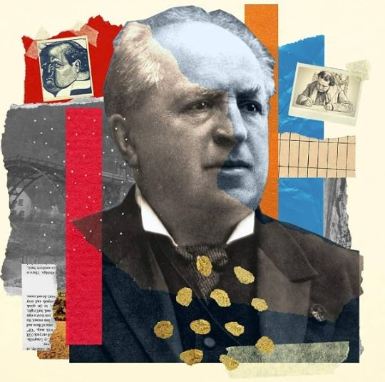

<sup>1</sup>Que os homens nos considerem como ministros de Cristo, e mordomos dos mistérios de Deus.

<sup>2</sup>Além disso, requer-se dos mordomos que cada um se ache fiel.

<sup>3</sup>Todavia, a mim mui pouco se me dá de ser julgado por vós, ou por algum juízo humano; nem eu tampouco a mim mesmo me julgo.

<sup>4</sup>Porque em nada me sinto culpado; mas nem por isso me considero justificado, pois quem me julga é o Senhor.

<sup>5</sup>Portanto, nada julgueis antes do tempo, até que o Senhor venha, o qual também trará à luz as coisas ocultas das trevas, e manifestará os desígnios dos corações; e então cada um receberá de Deus o louvor.

1 Coríntios 4:1-5 | ACF

## O papel do mordomo

No contexto bíblico, o mordomo (*oikonómos*) era um servo de grande confiança, que administrava os bens, a casa ou os negócios do seu senhor.

Paulo se via, junto com os outros apóstolos, como um despenseiro encarregado dos mistérios e do Evangelho de Deus.

<sup>1</sup>Que os homens nos considerem como ministros de Cristo, e mordomos dos mistérios de Deus.

<sup>2</sup>Além disso, requer-se dos mordomos que cada um se ache fiel.

<sup>3</sup>Todavia, a mim mui pouco se me dá de ser julgado por vós, ou por algum juízo humano; nem eu tampouco a mim mesmo me julgo.

<sup>4</sup>Porque em nada me sinto culpado; mas nem por isso me considero justificado, pois quem me julga é o Senhor.

<sup>5</sup>Portanto, nada julgueis antes do tempo, até que o Senhor venha, o qual também trará à luz as coisas ocultas das trevas, e manifestará os desígnios dos corações; e então cada um receberá de Deus o louvor.

## A principal exigência

O padrão exigido de quem ocupa essa posição não é o sucesso aos olhos do mundo, a popularidade ou a genialidade.

É a fidelidade àquele que o encarregou.

<sup>1</sup>Que os homens nos considerem como ministros de Cristo, e mordomos dos mistérios de Deus.

<sup>2</sup>Além disso, requer-se dos mordomos que cada um se ache fiel.

<sup>3</sup>Todavia, a mim mui pouco se me dá de ser julgado por vós, ou por algum juízo humano; nem eu tampouco a mim mesmo me julgo.

<sup>4</sup>Porque em nada me sinto culpado; mas nem por isso me considero justificado, pois quem me julga é o Senhor.

<sup>5</sup>Portanto, nada julgueis antes do tempo, até que o Senhor venha, o qual também trará à luz as coisas ocultas das trevas, e manifestará os desígnios dos corações; e então cada um receberá de Deus o louvor.

## Aprovação divina acima da humana

Nos versos 3 e 4, Paulo lembra que o julgamento mais importante não vem de tribunais humanos nem de críticas externas.

Vem do próprio Senhor.

<sup>1</sup>Que os homens nos considerem como ministros de Cristo, e mordomos dos mistérios de Deus.

<sup>2</sup>Além disso, requer-se dos mordomos que cada um se ache fiel.

<sup>3</sup>Todavia, a mim mui pouco se me dá de ser julgado por vós, ou por algum juízo humano; nem eu tampouco a mim mesmo me julgo.

<sup>4</sup>Porque em nada me sinto culpado; mas nem por isso me considero justificado, pois quem me julga é o Senhor.

<sup>5</sup>Portanto, nada julgueis antes do tempo, até que o Senhor venha, o qual também trará à luz as coisas ocultas das trevas, e manifestará os desígnios dos corações; e então cada um receberá de Deus o louvor.

[figure not shown]

## A vida é o nosso principal recurso

- Tudo ao nosso redor é recurso, e nós somos mordomos.
- Nós mesmos somos recurso por inteiro: carne, osso e sangue. Objetos e bens são só uma extensão.

Como você tem sido mordomo do bem mais precioso que Deus deixou ao seu cuidado?

<sup>19</sup>Ou não sabeis que o vosso corpo é o templo do Espírito Santo, que habita em vós, proveniente de Deus, e que não sois de vós mesmos?

<sup>20</sup>Porque fostes comprados por bom preço; glorificai, pois, a Deus no vosso corpo, e no vosso espírito, os quais pertencem a Deus.

1 Coríntios 6:19-20 | ACF

## Você reparou?

Dinheiro

Tempo

Bens

Amigos

[figure not shown]

Corpo

Todos esses recursos estavam diante dos nossos olhos o tempo todo, assim como boa parte dos recursos que temos na nossa vida.

Que possamos ser mais sensíveis e gratos por cada um deles.

## Refletir e aplicar

- **Agradecer.** Identificar e agradecer pelos recursos que Deus nos dá diariamente.
- **Ser fiel.** Administrar os recursos com fidelidade a Deus e lembrar de qual julgamento realmente devemos nos preocupar.
- **Inteiramente e integralmente.** Nosso ser como um todo é um recurso: não só os bens, mas a carne, o osso e o sangue. Viva a vida lembrando disso.

1 / 12